# Bikeshare data analysis year 2019

## by Abdulrahman Osama

## Investigation Overview

> In this analysis, I worked on finding some insights and user preferences like the most common hour of the day, day of the week, month of the year and the average time duration of trips and how all of these are affected by the type of user and the city where the ride took place.

## Dataset Overview

> The dataset consists of around 6 million trips for the year 2019 and their information including the time duration of the trips in seconds, the start date and time, and the user type. I have collected the data for two cities San Francisco and Washington DC.

## Trips duration distribution and its average

> The duration of trips has a very large range reaching to over 80000 seconds. When zooming in the histogram it we find it right skewed with average around 960 seconds

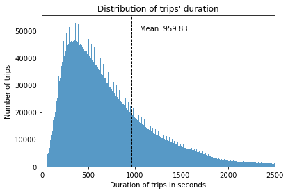

## Average duration of trips by different user types, cities, and days of the week

> Average duration of trips is different among the two cities. Also the average duration differ from day to day among the week. Weekends have longer average of duration than weekdays but customers always tends to make longer rides than subscribers.

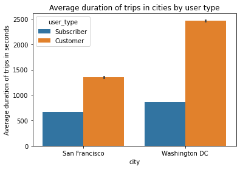

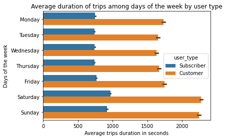

## Number of trips Vs. hour of the day by type of user and different days of the week

> During week days, people are taking rides to and from work creating two peaks one in the morning at 8:00 AM and the other at 17:00. While during weekends, people are taking longer rides normally distributed over the day from morning to midnight.

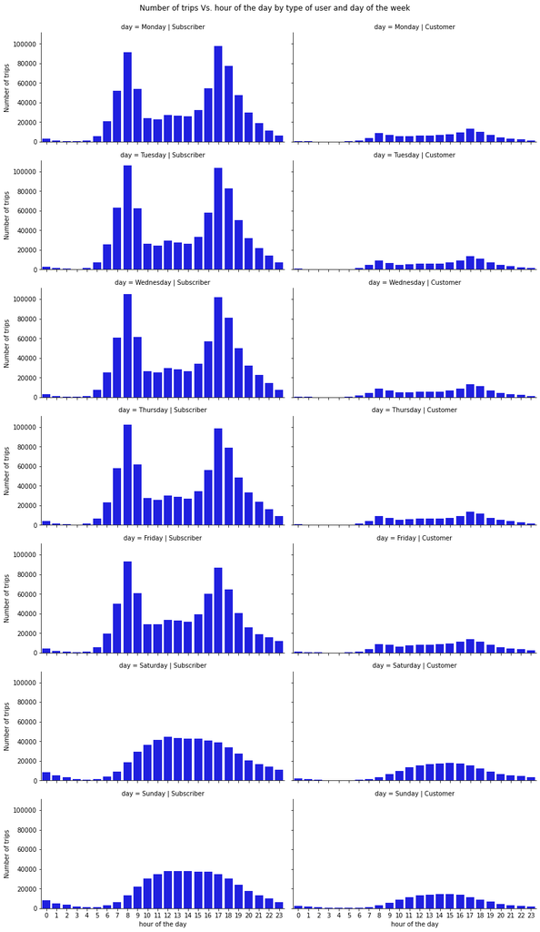

## Number of trips Vs. day of the week by type of user and the city

> For subscribers week days are more common to take rides than week ends in both cities, while for customers week ends are more common in Washington DC while in San Francisco all days are nearly the same.

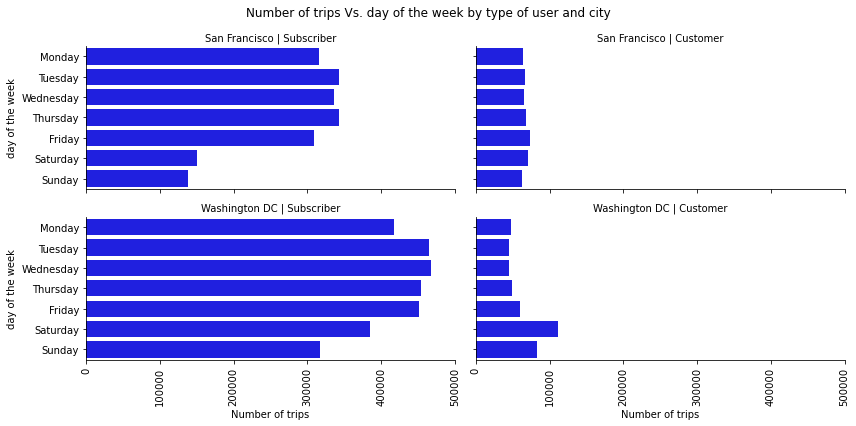